# Simulating the Luria Delbrück experiment

# Introduction

This R markdown document will form the basis from which you will write your own code to simulate the fluctuation (Luria-Delbrück) experiment. After every step, we will make sure everyone is on the same page, so if you’ll get stuck, don’t worry too much. A big part of modelling is just having fun and playing! =)

# Step 1) Modeling exponential growth

## Assumptions

- There is no cell death
- Every bacterium divides every time step

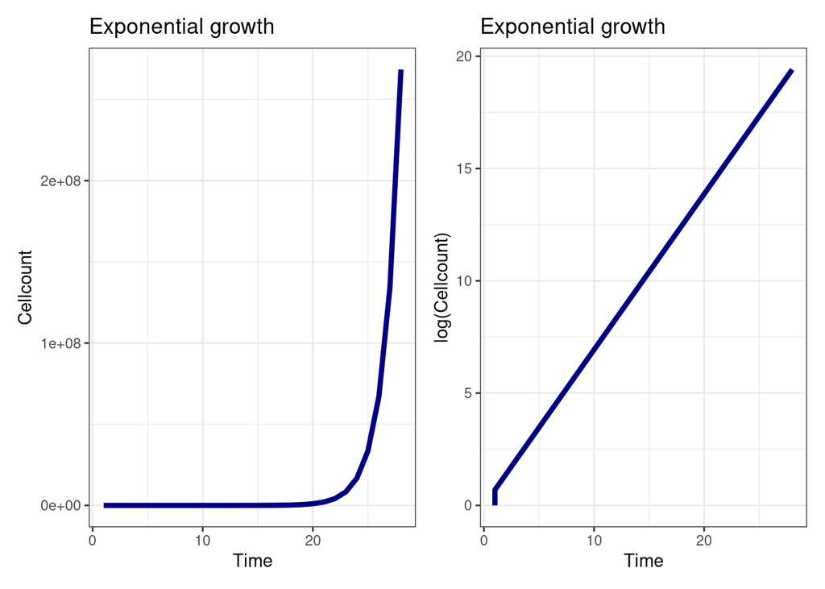

```r
# Below is a simple function to model exponential growth.
exponentialGrowth=function(maxPopsize){
  N <- 1 # Initial population size. In modelling, usually denoted with 'N'
  t <- 1 # Initial time point
  output <- data.frame(Time=t,Cellcount=N) # New (empty) dataframe containing two columns: Time, Cellcount
  while(N<maxPopsize){
     N <- 2*N   # Every cell divides, so the population size doubles
     output <- rbind(output,data.frame(Time=t,Cellcount=N)) # Add a row to the dataframe
     t<-t+1
  }
  return(output) # Return the dataframe
}

exp_growth=exponentialGrowth(P) # Run the simulation once, and store the result in "exp_growth"

## If you want to plot with base R, do this: plot(x=exp_growth$Time,y=exp_growth$Cellcount,type="l")

## But I like ggplot:
plot_norm <- exp_growth %>%
  ggplot(aes(x=Time,y=Cellcount)) +
  geom_line(col="navy",size=1.5) +
  ggtitle("Exponential growth")

plot_ylog <- exp_growth %>%
  ggplot(aes(x=Time,y=log(Cellcount))) +
  geom_line(col="navy",size=1.5) +
  ggtitle("Exponential growth")

plot_norm + plot_ylog
```

# Step 2) Including mutations

Extend the loop provided in step 1, to include mutations.

## Assumptions

- Mutations are neutral (mutants grow at the same rate at the wildtype)
- Mutations occur at every division at rate genomeLength * mutationRate (in both cells)
- No more than 1 mutation occurs per division, and there are no secondary mutations (i.e. mutants don’t mutate)

# Step 3) Only tracking RIF-resistant mutants, not ALL mutants

Extend your model to include ONLY mutations which infer rifampicin resistance.

- The total number of possible mutations is genomeLength * 3 (one for every substitution)
- The total number of substitutions that infer resistance is given by targetSize (either from Lindsey et al., or your own data)

# Step 4) Final code: repeating the experiment N times

Now, let’s repeat the experiment 132 times, like we did in the lab.